# Spatio-temporal analysis of dengue fever in Brazil and its relationship to climate stressors

02364467

07/04/2023

# Abstract

Dengue fever is a frequent epidemic in Brazil and has proven to be a large burden on the healthcare system of Brazil. The increase in temperatures from global warming has and will increase the risk upon areas of Brazil that where once unaffected as mosquito population densities increase . In this paper we evaluate the spatio-temporal patterns of dengue using Bayesian models and Integrated Nested Laplace Approximation across a 5 year time period (2015-2019) to understand the way in which dengue fever is spread across Brazil and the effects of climatic stressors like temperature and drought have on the spread. We find that the build-up of the virus begins in the most northern regions of Brazil and the high number of dengue fever cases are perpetuated by factors in the south eastern region containing the big cities like Rio and Sao Paulo.Climatic stressor seem to have a small effect on dengue cases however there is a chance these covariate effects are being clouded by spatial effect confounding and may need further analysis. The results highlight the importance of focusing health resources on the most northern regions of Brazil to mitigate the spread of the disease.

# Introduction

Dengue is a globally expanding virus that can cause symptoms that range from a fever to more extreme cases of severe hemorrhaging (Zerfu, Kassa, and Legesse 2023) . As global warming increases global temperature , a common vector for the Dengue virus the aedes aqgypti mosquito has found more environments hospitable than before , exposing the virus to a much larger global population with putting near to a billion new people at risk within this century (Ryan et al. 2019). Brazil has been no stranger to the expansion of this virus as it has been shown to reach areas at higher latitudes and has effected 481 municipalities that have reports of dengue for the first time putting an additional 8.1 million people at risk. With the northern and southern regions being effected more due to their links with urbanization and global warming(Codeco et al. 2022).

To combat this Brazil has created a formidable surveillance system to look at the spread in dengue fever in an attempt to mitigate these cyclical dengue epidemics. However while the surveillance is robust , the healthcare system suffers from a lack of health inclusivity due to no universal healthcare availability and therefore the resources to deal with dengue fever are minimal relative to the virus outbreak numbers(Angelo et al. 2020). Being more specific in identifying these high risk areas and areas where dengue cases build up can help identify areas where these minimal health care resources can be allocated

# Aims

The aim of this study is to analyze the spatio-temporal patterns of dengue fever outbreaks in Brazil over a 5-year period, using high-resolution micro region data. We also aim to evaluate the impact of climatic stressors on the spread of the disease. By identifying the factors that contribute to the cyclical nature of dengue fever outbreaks and the potential impact of climatic stressors, we hope to inform the development of targeted public health interventions aimed at reducing the spread of the disease in Brazil.

# Methods

**Pre-processing**

**Initial SMR analysis**

First a simple SMR analysis of the relative risk was conducted. In which $SMR_i = y_i /e_i$ where $y_i$ is the sum of observed cases per microregion over 5 years (60 months) $E_i$ is the sum of expected cases of microregion where $E_i = \frac{1}{10^5} \sum_{j=1}^{n} p_{ij}$ and $i$ = microregion , $n$ = total number of microregions and $j$ = index of each microregion . Dividing by 10^5 allows to standardize the expected cases by converting them to an incidence rate per 100,000 people. The SMR of each microregion was then plotted (supplementary 2). This was used as a baseline to compare the model to more complex models that incorporate spatial and temporal effects.

**Spatial analysis**

A graph based on a hierarchical poisson log linear model is plotted. This is model is defined as :

$$\begin{eqnarray}O_i &\sim & \text{Poisson}(\rho_i E_i)\\\eta_i
&= & \log \rho_i = b_0 + b_i\\\boldsymbol{b} &=
&\frac{1}{\sqrt{\tau_b}}(\sqrt{1-\phi}\boldsymbol{v}_{*}
+\sqrt{\phi}\boldsymbol{u}_{*})\\\end{eqnarray}$$

Where $O_i$ represents the dengue cases ($O$ ) in reigon $i$ and assumes a poisson distribution with a mean of $\rho_i E_i$ with $E_i$ = expected cases and $\rho_i$ representin the relative risk in micro region $i$ compared with the overall relative risk. A log linear function is used to model $\rho_i$ with $b_0$ = fixed effect and $b_1$ = random effects. $\boldsymbol{b}$ represents the vector which will represent the random effects with the spatial structure being incorporated captured ICAR model in which $\boldsymbol{v}*$ is the standardized spatial structured adjacency between regions and $\boldsymbol{u}*$ = the spatially unstructured component.

The formula uses ID to identify each micro region , the adjacency matrix is held in the shape.adj object . To incorporate the ICAR structured model and the spatially unstructured effect a BYM2 model is used in which hyperparamter pc.prec and phi are used with their corresponding priors mentioned in the param argument to define the spatially structured and unstructured effects respectively (supplementary 4). No climatic stressor covaraites where used due to the inability of the model to converge. The waic is extracted to compare the two models also using the general formula used for each model (supplementary 3)

**Spatio-temporal analysis**

$$\begin{eqnarray}O_{it} &\sim &
\text{Poisson}(\rho_{it} E_{it}) \\\log \rho_{it} &= & b_0 + b_i
+ \gamma_t + \psi_t \\\boldsymbol{b} &=
&\frac{1}{\sqrt{\tau_b}}(\sqrt{1-\phi}\boldsymbol{v}_{*}
+\sqrt{\phi}\boldsymbol{u}_{*})\\\gamma_t & \sim &
\hbox{RW(1)}\\\psi_t & \sim &
N(0,\sigma^2_{\psi})\\\end{eqnarray}$$

Where the priors from the previous spatial analysis are maintained a temporal component is added to the equation represented by $t$ to incorporate the temporal effect. In additon to this $\gamma_t$ is added which is a temporal random effect added with a rank 1 random walk in which we assume the observations and the previous observation before it are normally distributed with mean 0 and variance 1. Relating the temporal effect $t$ to the previous temporal random effect indexed by $t-1$ with a degree of randomness. $\psi_t$ is a temporal autocorrelation effect with an assumed normal distribution and a correlation between time point $\psi_t$ and $\psi_{t-1}$ where time that are further apart are less likely to be similar. Both $\gamma_t$ and $\psi_t$ have been incorporated in the f(ID_time,model”rw1”) in the formula(supplementary 5).The Relative Risk and Posterior probabilities are then extracted using the extraction general extraction algorithm used for each model. (supplementary 6).

**Spatio-temporal interaction (type 1 interaction)**

The spatio temporal interaction can be described as :

$$\begin{eqnarray}
O_{it} &\sim & \text{Poisson}(\rho_{it} E_{it}) \\
\log \rho_{it} &= & b_0 + b_i + \gamma_t + \psi_t + \delta_{it}
\\
\boldsymbol{b} &= &
\frac{1}{\sqrt{\tau_b}}(\sqrt{1-\phi}\boldsymbol{v}_{*} +
\sqrt{\phi}\boldsymbol{u}_{*})\\
\gamma_t & \sim & \hbox{RW(1)}\\
\psi_t & \sim & N(0,\sigma^2_{\psi})\\
\delta_{it} & \sim & \hbox{Normal}(0, \sigma^2_{\delta})
\end{eqnarray}$$

While maintaining previous priors and parameters mentioned in spatial and spatio-temporal analyis wihout an interaction , a normal distibuted space time interaction paramter $\delta_{it}$ . This will account for any space time interaction that was not seen before and any in addition accounts for any additional covariate interaction across space and time. This is in incorporated f(ID.space.time,model = “iid”) in the formula (supplementary 7)

**Spatio-temporal interaction type IV**

Here instead of assuming the spatio-temporal interaction is linear , it is assumed that the spatio temporal interaction can shift in direction and strength. To do this the formula used and the ilna method are completely changed to implement this complex model per instruction from Goicoa et al. (2017). First a temporal structure was defined using RW1 model priors. Then a uniform distribution is implements on the standard deviation of random effects. We then define the spatial neighborhood matrix using the .graph model containing the neighbors and weights between the neighbors . Kronecker priors are formed to help define the type IV interaction using the RW1 in the formula (supplementary 8).Here “generic1” is used as the model for ID_space to incorporate an ICAR prior, “rw1” was used to define the temporal element and “generic0” was used to define a generic Gaussian prior to be used all in which the “sdunif” prior is responsible to apply the uniform distribution upon the random effects .

# Results

## Exploratory analysis

**Initial temporal analysis**

**Initial regional analysis**

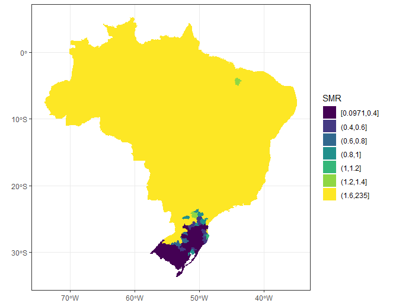

Figure 1: plot of SMR across microregion in Brazil between 2015-2019

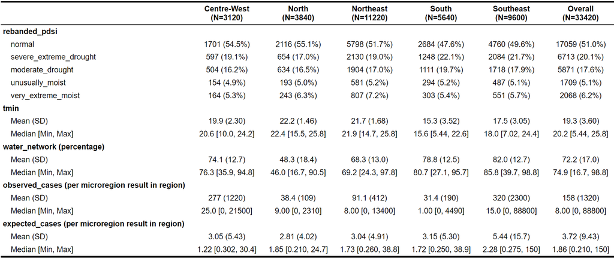

Table 2 : Table showing stats for the covariates and observed and expected cases for each major region in Brazil based on averages taken from 60 results per micro region over the 60 month time period

## Spatial and Spatio-temporal analysis

**Comparing plots**

[figure not shown]

Figure 2: This figure plots the Relative Risk (RR) and Posterior probability (PP) of a spatial model and Spatio-temporal (ST) model of Brazil.

The initial spacial model and and spatio-temporal model are very similar and show clustering of high Relative Risk toward central Brazil. Based upon the posterior probability the degree of certainty within this central cluster is very high however both models show a low degree of certainty near the southern region where the observed cases are low in some areas, the models also struggle with the northern regions . It is clear that just adding a temporal effect and covariates to the model is not enough to show the underlying patterns within the data.

**Adding Spatio-temporal interaction terms**

[figure not shown]

Figure 3: This shows the RR and PP plots of spatio temporal models with type I interaction (top row) and Type IV interaction (bottom row)

When we add a type I interaction the maximum relative risk increases by nearly double as more northern areas are incorporated into the model suggesting that there is in fact a spatio-temporal interaction that is changing the model drastically (figure 3). While type 1 interaction assumes a fixed spatial pattern , type 4 interaction model do not (supplemetary 9). Type 4 models where explored to see if the model can better interpret the spatial - temporal interaction over time. Looking at the type 4 interaction plot it is clear that there does seem to be changing pattern as now the high Relative Risk cluster moves further north and again a higher relative risk is incorporated at 66.1 as more northern regions are considered high risk in the model. When looking at the underlying interaction across the 60 months , a pattern arises , in which when dengue cases are low the interaction is high in the more northern regions then the interaction moves to the south and south eastern regions when the dengue cases rise (supplementary 9).

**Comparing covariate cilmatic stressors**

**Watanabe-Akaike information criterion (WAIC)**

Table 3 : Table showing the WAIC of each model with and without covariates

| Model | Waic (with cov) | WAIC (without cov) |
| --- | --- | --- |
| Spatio-temporal model no interaction | 21919663 | 21708939 |
| Spatio-temporal model type I interaction | 195923.1 | 216278.2 |
| Spatio-temporal model type IV interaction | 196229.48 | 196777.8 |

**Analyzing the fixed effects**

Table 4 : Table showing the multiplicative factor e^(mean) of each fixed effects’ relationship to response variable (dengue case count)

| Fixed effects: |  |  |  |
| --- | --- | --- | --- |
|  | Multiplicative factor | mean | sd |
| (Intercept) |  | -2.734 | 0.235 |
| tmin | 1.17 | 0.156 | 0.005 |
| rebanded_pdsisevere_extreme_drought | 0.98 | -0.02 | 0.029 |
| rebanded_pdsimoderate_drought | 1.06 | 0.055 | 0.024 |
| rebanded_pdsiunusually_moist | 1.00 | -0.001 | 0.041 |
| rebanded_pdsivery_extreme_moist | 0.97 | -0.034 | 0.045 |
| water_network | 1.02 | 0.016 | 0.003 |

# Discussion and conclusion

The results do overall show a spatio-temporal interaction when looking at dengue fever. We see that when we consider that the interaction between the micro regions is modeled a a non - fixed effect that can change direction and magnitude of the spatio-temporal interaction between micro regions. Incorporating these interaction within this model we are able to identify the northern regions that seem to be most at risk when looking at these interaction. When looking at interaction across the 60 months the pattern in the northern regions (2017 - 2018) suggest that the build up of dengue cases occurs in the most northern regions and spreads towards the south eastern regions over time. Moving into 2019, when dengue cases are much higher, the interaction term is highest in the south eastern regions suggesting that the big cities like Rio and Sao Paulo become are responsible for spreading the disease at it peaked. Based on this we propose that dealing with dengue fever at the build up in the North may ease the burden during the a dengue fever outbreak in the larger cities later. However as we can see from the posterior proabilities , no model is able to completely explain the spatio-temporal patterns especially in the most northern and southern regions. This could be due to the low number of observed cases in those regions . We suggest a sub analysis in the future to look more specifically at the southern and northern regions or to incorporate parameters within the models that may be able to explain drastic changes in cases between regions.

Looking at the covriates involved in these models , the evidence show small multiplicative effect upon the number of dengue cases. This may be due to confounding between the spatial random effects , which has been known to effect result of the fixed effect covariates. New models , involving restricted regression can be used to alleviate this confounding making results clearer Adin et al. (2021).

Given that the northern regions of Brazil show high relative risk for dengue fever and dengue epidemics build up in the north , the effects of global warming may cause more drastic effects as mosquitoes start to find the north more habitable . Already papers have shown that the density of mosquito populations will increase as temperature rise , increasing the amount of dengue vector available Bonnin et al. (2022). Future analysis is required to further understand the relationship between global warming , dengue vectors and dengue fever in Brazil.